# Week 11: Genetic drift and simulating the Buri experiment

```python
import numpy as np
import numba
import random
import matplotlib.pyplot as plt
import scipy.integrate

import seaborn as sns
sns.set(font_scale = 1.5, rc={"lines.linewidth":2})
```

## Simulating a single vial of a Buri experiment

Let's simulate how a single vial might drift over time in the Buri experiment. We will first initialize some parameters:

```python
# number of flies in each vial
n_flies = 16

# number of generations to run the simulation
n_generations = 20

# initilaize an array to store the frequency of the red allele
r_freq = np.zeros(n_generations)
r_freq[0] = 0.5
```

How will the allele frequency change over time for our vial? Using the "bag of alleles" approximation, we will draw the next generation's 32 alleles, each with a `0.5` chance of being red. For this we can use `np.random.binomial(n, p)`, where `n` will be the number of alleles we want and `p` will be the probability of grabbing a red allele out of our "bag".

As an example:

```python
n = n_flies * 2
p = 0.75

# how many red alleles do we get?
np.random.binomial(n, p)
```

```
25
```

Using this approach for generating the next generation's red allele frequency, let's simulate a single vial over time, updating the frequency at each generation:

```python
for i in range(1, n_generations):
    p = r_freq[i-1]
    # how many red alleles do we get?
    #we want p to change with the value of the red
    num_red = np.random.binomial(n,p)

    new_r_freq = num_red / (n_flies*2)

    r_freq[i] = new_r_freq
r_freq
```

```
array([0.5    , 0.53125, 0.5    , 0.5    , 0.5    , 0.46875, 0.4375 ,
       0.375  , 0.3125 , 0.21875, 0.21875, 0.1875 , 0.125  , 0.15625,
       0.15625, 0.1875 , 0.1875 , 0.09375, 0.09375, 0.09375])
```

Plotting the results. Does the red or white allele become fixed?

```
(0.0, 1.0)
```

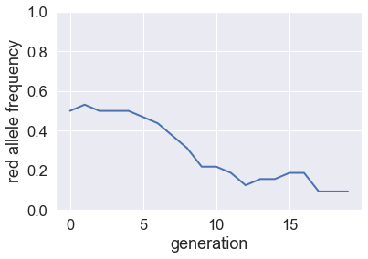

```python
plt.plot(r_freq)
plt.xlabel("generation")
plt.ylabel("red allele frequency")
plt.ylim([0,1])
```

## Problem 1 -- Simulating the full Buri experiment

Extend what we've done so far to model the entire Buri experiment, tracking 107 vials over 20 generations. For this, we will want to use a 2D-array, such as `red_freq = np.zeros([n_vials, n_generations])` to store our allele frequencies in.

Plot the distribution of the red allele frequency at the end of the 20 generations. It should look something like this:

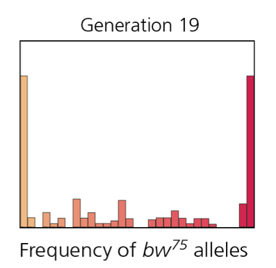

```python
#params
n_vials = 107
n_generations = 20
n_flies = 16
```

```python
# initilaize an array to store the frequency of the red allele
red_freq = np.zeros([n_vials, n_generations])
#initializes the frist draw from every vial
red_freq[:,0] = 0.5
```

```python
for j in range(1,n_vials):
    for i in range(1, n_generations):
        n = n_flies * 2
        p = red_freq[j, i-1]
        # how many red alleles do we get?
        #we want p to change with the value of the red
        numb_red = np.random.binomial(n,p)

        new_red_freq = numb_red / n

        red_freq[j,i] = new_red_freq
```

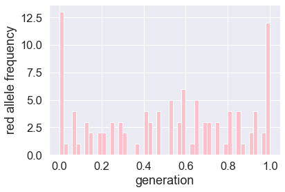

```python
plt.hist(red_freq[:,-1], bins = 50, color = "pink")
plt.xlabel("generation")
plt.ylabel("red allele frequency")
```

## Problem 2 -- Modifying the population size

Rerun your simulation for `n_flies = 8` and `n_flies = 32` and plot your results. From your results, how do population size and genetic drift relate?

```python
#params
n_vials = 107
n_generations = 20
n_flies = 8
```

```python
# initilaize an array to store the frequency of the red allele
red_freq = np.zeros([n_vials, n_generations])
#initializes the frist draw from every vial
red_freq[:,0] = 0.5
```

```python
for j in range(1,n_vials):
    for i in range(1, n_generations):
        n = n_flies * 2
        p = red_freq[j, i-1]
        # how many red alleles do we get?
        #we want p to change with the value of the red
        numb_red = np.random.binomial(n,p)

        new_red_freq = numb_red / n

        red_freq[j,i] = new_red_freq
```

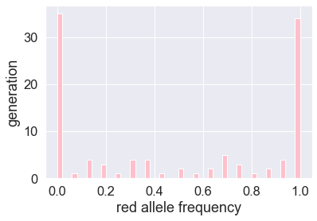

```python
plt.hist(red_freq[:,-1], bins = 50, color = "pink")
plt.xlabel("red allele frequency")
plt.ylabel("generation")
```

```python
#params
n_vials = 107
n_generations = 20
n_flies = 32
```

```python
# initilaize an array to store the frequency of the red allele
red_freq = np.zeros([n_vials, n_generations])
#initializes the frist draw from every vial
red_freq[:,0] = 0.5
```

```python
for j in range(1,n_vials):
    for i in range(1, n_generations):
        n = n_flies * 2
        p = red_freq[j, i-1]
        # how many red alleles do we get?
        #we want p to change with the value of the red
        numb_red = np.random.binomial(n,p)

        new_red_freq = numb_red / n

        red_freq[j,i] = new_red_freq
```

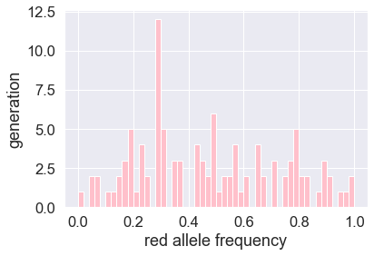

```python
plt.hist(red_freq[:,-1], bins = 50, color = "pink")
plt.xlabel("red allele frequency")
plt.ylabel("generation")
```

**From your results, how do population size and genetic drift relate?**

Looking at my results, we can see the correlation between genetic drift an population size based on where the frequency lies. With a smaller popualtion our frquency has an automatic tendency to shift towards 0 or 1, whereas if we have a larger population size, we have more variation within the middle of our graph or "fixation" in the middle of our graph.

## Problem 3 -- Modifying the number of generations

Returning to `n_flies = 16`, run the simulation for 100 generations and plot your results. From your results, what role does time seem to play in genetic drift?

```python
#params
n_vials = 107
n_generations = 100
n_flies = 16
```

```python
# initilaize an array to store the frequency of the red allele
red_freq = np.zeros([n_vials, n_generations])
#initializes the frist draw from every vial
red_freq[:,0] = 0.5
```

```python
for j in range(1,n_vials):
    for i in range(1, n_generations):
        n = n_flies * 2
        p = red_freq[j, i-1]
        # how many red alleles do we get?
        #we want p to change with the value of the red
        numb_red = np.random.binomial(n,p)

        new_red_freq = numb_red / n

        red_freq[j,i] = new_red_freq
```

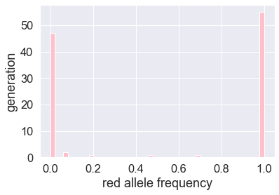

```python
plt.hist(red_freq[:,-1], bins = 50, color = "pink")
plt.xlabel("red allele frequency")
plt.ylabel("generation")
```

**From your results, what role does time seem to play in genetic drift?**

Increasing your generation size, delivers the same effect as having a smaller population size. This shows that it will shift towards either 1 or 0, inhibiting any variation in the middle of the graph. With an infinite amount of generations you are bound to see this occur.

## Problem 4 -- Going beyond "bag of alleles"

Model this population over time, taking the following steps:

- Pick two flies at random from the population
- From each fly, pick an allele at random
- Use these two alleles to generate a new fly and save it as part of a new population
- Repeat this process `n_flies` times until you have produced a new population of 16 files

With this new population in hand, you can record the new frequency of the red allele and repeat the whole process again for 20 generations. Plot the frequency of the red allele over time for this vial. For now we won't worry about simulating this for 107 vials.

```python
# 16 orange flies, each with a red (1) and white (0) aelele
pop = np.array([[1,0]] * n_flies)
```

```python
#params
n_flies = 16
n_gen = 20
r_freq = np.zeros(n_gen)
r_freq[0] = 0.5
```

```python
#looping through generations
for g in range(1,n_gen):
    #the first list (we will put a list within this list)
    new_population = []
    #going through the population within each generation
    for i in range(len(pop)): #generating an array of 1 and 0
        num1, num2 = np.random.choice(range(len(pop)), 2, replace=False) #its false because we dont want it to select the same number twice
        #selecting the 0 and 1 combo and assigning it to a variable
        #select random 2 flies
        fly1 = pop[num1]
        fly2 = pop[num2]
        #gathering a random number from an array NOT a range, the 0 is for the weights and its making sure there is no bias
        allele1 = random.choices(fly1)[0]#selcting random 2 alleles
        allele2 = random.choices(fly2)[0]
        new_fly  = [allele1, allele2]
        new_population.append(new_fly)
    #overwriting to continue to grab new values
    pop = np.array(new_population)
    #change the frequency
    r_freq[g] = pop.sum()/(n_flies*2)
```

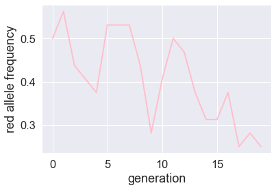

```python
plt.plot(r_freq, color = "pink")
plt.xlabel("generation")
plt.ylabel("red allele frequency")
```